# Manage Roles

[[edit on GitHub]](https://github.com/chef/chef-web-docs/blob/main/content/server_manage_roles.md)

[figure not shown]

Warning

Chef Manage is deprecated and no longer under active development. It is supported on Chef Automate installations up to version 1.8 and replaced by Chef Automate 2.0. Contact your Chef account representative for information about upgrading your system. See our Automate documentation to learn more about Chef Automate 2.

This document is no longer maintained.

Note

This topic is about using the Chef management console to manage roles.

A role is a way to define certain patterns and processes that exist across nodes in an organization as belonging to a single job function. Each role consists of zero (or more) attributes and a run-list. Each node can have zero (or more) roles assigned to it. When a role is run against a node, the configuration details of that node are compared against the attributes of the role, and then the contents of that role’s run-list are applied to the node’s configuration details. When a Chef Infra Client runs, it merges its own attributes and run-lists with those contained within each assigned role.

## Manage

Roles can be managed from the Chef management console web user interface.

### Add Role

To add a role:

1. Open the Chef management console.
2. Click **Policy**.
3. Click **Roles**.
4. Click **Create**.
5. In the **Create Role** dialog box, enter the name of the role and a description.

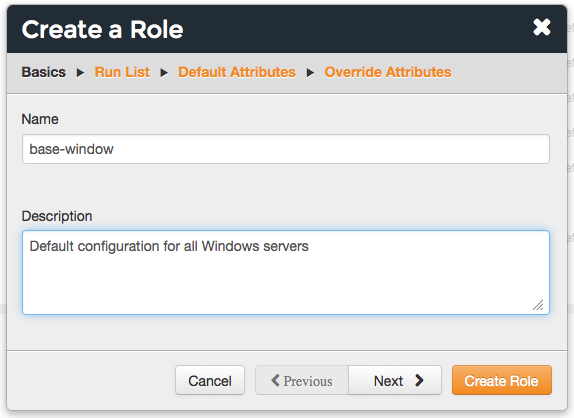

   Click **Next**.
6. Optional. Build the run-list from the list of available roles and recipes:

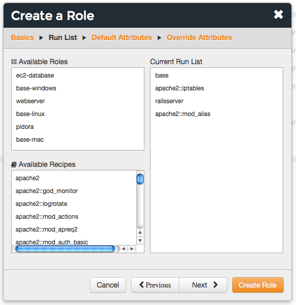

   Click **Next**.
7. Optional. Add default attributes as JSON data:

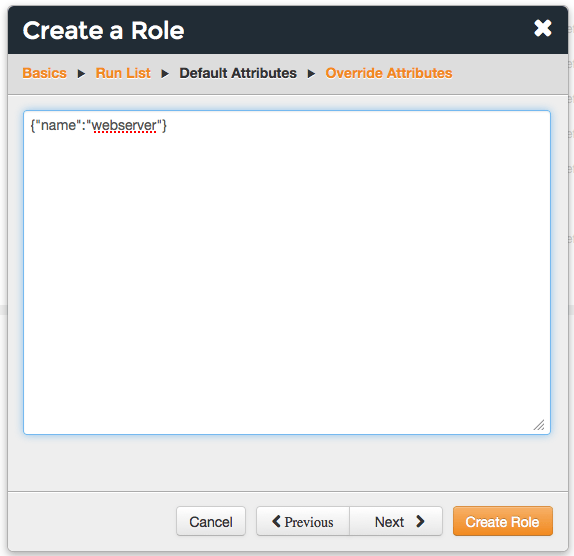

   Click **Next**.
8. Optional. Add override attributes as JSON data:

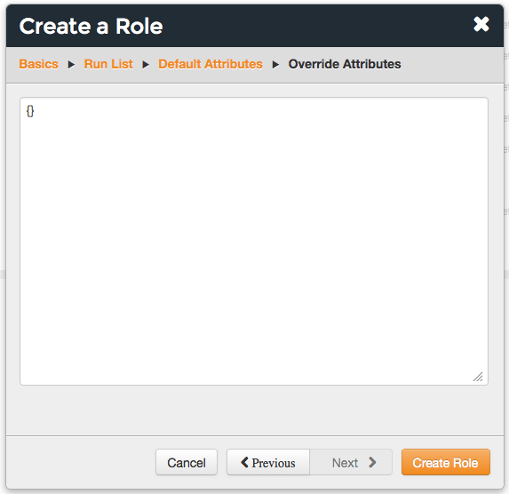

9. Click **Create Role**.

### Delete Role

To delete a role:

1. Open the Chef management console.
2. Click **Policy**.
3. Click **Roles**.
4. Select a role.
5. Click **Delete**.

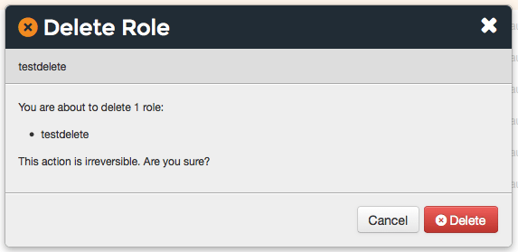

### View All Roles

To view all roles uploaded to the Chef Infra Server organization:

1. Open the Chef management console.
2. Click **Policy**.
3. Click **Roles**.

## Run-lists

A run-list defines all of the information necessary for Chef to configure a node into the desired state. A run-list is:

- An ordered list of roles and/or recipes that are run in the exact order defined in the run-list; if a recipe appears more than once in the run-list, Chef Infra Client will not run it twice
- Always specific to the node on which it runs; nodes may have a run-list that is identical to the run-list used by other nodes
- Stored as part of the node object on the Chef server
- Maintained using knife and then uploaded from the workstation to the Chef Infra Server, or maintained using Chef Automate

### Edit Role Run-list

To edit the run-list for a role:

1. Open the Chef management console.
2. Click **Policy**.
3. Click **Roles**.
4. Select a role.
5. Click **Edit Run List**.

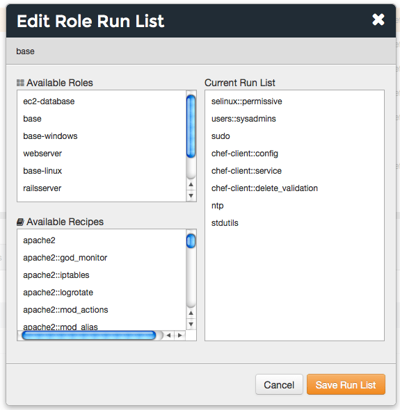

6. Make your changes.
7. Click **Save Run List**.

## Default Attributes

A `default` attribute is automatically reset at the start of every Chef Infra Client run and has the lowest attribute precedence. Use `default` attributes as often as possible in cookbooks.

### Edit Default Attributes

To edit default attributes for a role:

1. Open the Chef management console.
2. Click **Policy**.
3. Click **Roles**.
4. Select a role.
5. Click the **Attributes** tab.
6. Under **Default Attributes**, click **Edit**.
7. In the **Edit Role Attributes** dialog box, enter the JSON data that defines the attribute (or attributes).

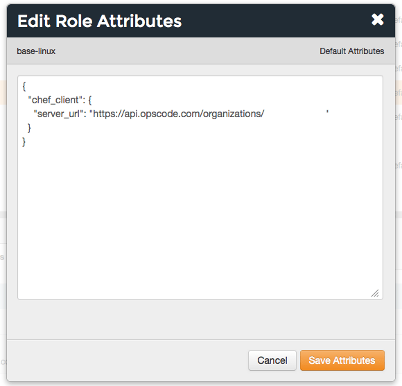

8. Click **Save Attributes**.

### View Default Attributes

To view default attributes for a role:

1. Open the Chef management console.
2. Click **Policy**.
3. Click **Roles**.
4. Select a role.
5. Click the **Attributes** tab.

## Override Attributes

An `override` attribute is automatically reset at the start of every Chef Infra Client run and has a higher attribute precedence than `default`, `force_default`, and `normal` attributes. An `override` attribute is most often specified in a recipe, but can be specified in an attribute file, for a role, and/or for an environment. A cookbook should be authored so that it uses `override` attributes only when required.

### Edit Override Attributes

To edit override attributes for a role:

1. Open the Chef management console.
2. Click **Policy**.
3. Click **Roles**.
4. Select a role.
5. Click the **Attributes** tab.
6. Under **Override Attributes**, click **Edit**.
7. In the **Edit Role Attributes** dialog box, enter the JSON data that defines the attribute (or attributes).

[figure not shown]

8. Click **Save Attributes**.

### View Override Attributes

To view role details:

1. Open the Chef management console.
2. Click **Policy**.
3. Click **Roles**.
4. Select a role.
5. Click the **Details** tab.

## Permissions

Permissions are used in the Chef Infra Server to define how users and groups can interact with objects on the server. Permissions are configured per-organization.

The Chef Infra Server includes the following object permissions:

[output not shown]

### Set

To set permissions list for a role object:

1. Open the Chef management console.
2. Click **Policy**.
3. Click **Roles**.
4. Select a role.
5. Click the **Permissions** tab.
6. For each group listed under **Name**, select or de-select the **Read**, **Update**, **Delete**, and **Grant** permissions.

### Update

To update the permissions list for a role object:

1. Open the Chef management console.
2. Click **Policy**.
3. Click **Roles**.
4. Select a role.
5. Click the **Permissions** tab.
6. Click the **+ Add** button and enter the name of the user or group to be added.
7. Select or de-select **Read**, **Update**, **Delete**, and **Grant** to update the permissions list for the user or group.

### View

To view permissions for a role object:

1. Open the Chef management console.
2. Click **Policy**.
3. Click **Roles**.
4. Select a role.
5. Click the **Permissions** tab.
6. Set the appropriate permissions: **Delete**, **Grant**, **Read**, and/or **Update**.